# Making Yourself Easy to Hire

Work History and Accountability

Author

Liana D. Bruce, PhD | [Bruce Analytics](https://bruceanalytics.com/marketplace-preview)

Published

May 9, 2026

📘 **Jump to:** Generate Your Excel Career Workbook

🔧 **Jump to:** Code a Table of Contents into Any Excel

## The overarching theme

Employers want to see you as a **safe investment**: someone trustworthy, responsible, and likely to help them make money rather than create headaches.

## Tip 1: Be where you said you’d be, and follow instructions exactly

A story making the rounds on Reddit (so take with a grain of redditsalt) is that someone showed up at a Quest lab for a pre-employment drug test. The lab kept them waiting over an hour to pee (yikes). They were getting late for their other job, so they got permission to leave and came back later for a fresh test code. The lab invalidated the original test, and the job offer was rescinded.

The lesson is not really about drug tests. It is about:

- Avoiding even the *appearance of impropriety*
- Being where you said you would be
- Following exact instructions, even when your reasoning for deviating seems sound

Compare this to working with AI. When you tell it “don’t include a header” and it puts one in anyway, you immediately start questioning everything else it produces. Employers feel the same way about new hires. People give you money when you help them, not when they have to correct you every two minutes.

## Tip 2: Keep an Excel of all your job data to help you

Background checks for jobs and mortgages need exact employment history and will verify the names and dates you give them. If you give them info they can verify quickly, it will speed things up

### Record who actually paid you

If you worked at a client site through a staffing firm, the staffing firm is your **verification employer** because they issued the W-2. The client is your **resume employer**, where the work actually happened. Background checks need the verification employer where the exact dates can be checked from whoever issued your paycheck. People often list the client on their resume and forget who the actual employer of record was, or they may volunteer work, or pull a month and year from memory and cause a discrepancy. A single mix-up can delay a start date by a week or more.

### Verification of service

Different employers use different third-party services to confirm employment. The Work Number (theworknumber.com) is the most common. Truv is another. Note which service each employer uses so you can tell the background-check vendor where to look, and give them a clean list.

### What to keep, organized as separate sheets

Here is the structure I use. Each one is a separate tab in the workbook so you can copy-paste the right slice into whatever form is asking for it.

- **Work History** one row per job. Verification employer, resume employer, exact start and end dates, title, supervisor, supervisor contact, salary, full-time vs. part-time, reason for leaving.
- **Education** schools, dates attended, degree, major, GPA, registrar contact.
- **Skills** software, languages, certifications, technical skills. Useful for filling in the “skills” section of online applications without having to think.
- **ESS_Verification** Employee Self-Service (or HR portal) verification details for each employer: login URL, employee ID, dates of access.
- **Work_History_Verification** for each job, who verifies it (the company directly, The Work Number, Truv, etc.), the URL or phone number, and any employer codes you need to provide.
- **Background_Check_Log** every time someone runs a background check on you, log it: date, requester, vendor, scope, result. Useful when a future check turns up something stale and you need to show the prior clean result.
- **Federal_Employment** federal applications need extra detail (USAJOBS-style fields: hours per week, salary at start and end, supervisor permission to contact, address of employer at the time you worked there).
- **Education_Paste** pre-formatted text blocks you can paste into application forms that ask for education in a specific way.
- **Transcript_Detail** courses, grades, credit hours. Gets asked for in academic and federal contexts and pulling it from old transcripts every time is painful.
- **ESS_Verification_Plain** a plain-text mirror of ESS_Verification with no formatting, for systems that strip rich text.
- **Publications** citations in the format you’d put in a CV. Some applications want them listed individually, some want a count, some want a link to your ORCID.

### See an example

| Company | Position | Location | Start | End | Verification |
| --- | --- | --- | --- | --- | --- |
| Genesis Research Group | Principal Scientist, Analytics | Hoboken, NJ | Sep 2024 | Present | Work Number |
| Dove Medical Press / Taylor & Francis | Editor in Chief | Macclesfield, England | Aug 2016 | Mar 2024 | None in US |
| Somatus | Senior/Principal Research Data Scientist | McLean, VA | Aug 2021 | Jan 2024 | Truv |
| Blu Omega (serving The Lewin Group/Optum Serve) | Senior Health Economist | Ashburn, VA | Apr 2024 | Aug 2024 | Work Number |
| University of North Carolina at Chapel Hill | Data Scientist, Sheps Center for Health Services Research | Chapel Hill, NC | Feb 2021 | Aug 2021 | Direct HR verification |
| Blue Cross and Blue Shield of North Carolina | Senior Insights Analyst | Durham, NC | Dec 2019 | Feb 2021 | Via Matrix/Motion Recruitment - check if on Work Number |

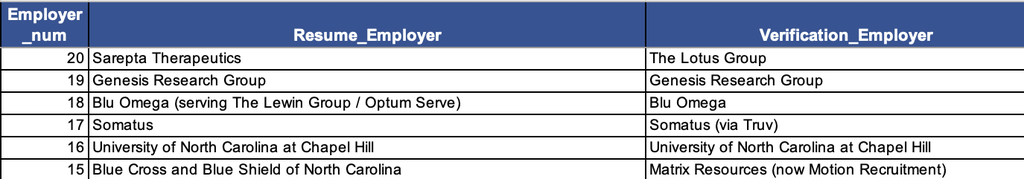

Example worksheet

### Generate yours

Download a ready-made example workbook below. It is free to use, with an optional $5 donation if it saves you time. In the future, you’ll be able to upload your resume or give us your LinkedIn URL at the [Bruce Analytics marketplace (preview)](https://bruceanalytics.com/marketplace-preview) and get a complete, personalized version back in your inbox. Your data will be parsed in your browser and never stored on our servers.

[⬇ Download the example workbook](https://github.com/ldbruce-2018/bcac-careertools1/raw/main/Resume_Data_for_Applications_with_TOC_example.xlsx)

Found it useful? Leave an optional $5 tip — no pressure, no paywall.  
[Tip $5 via Stripe](https://buy.stripe.com/7sY6oG0Yf9p1ai1f750sU00)

Use your workbook to:

- filter and sort through volunteer work/contract work, giving work verification services the exact information they can use to breeze through your background check
- apply for jobs, loans, and school in minutes rather than hours
- give landlords a verifiable list showing accountability and completeness
- tailor your resume for ATS and cover letters
- give AI the inputs it needs to work for you rather than soak up your whole day

Create once, add to it as you go, and spend downtimes “touching grass” as my teenager says.

### Key Methods for Verifying Federal Employment

- The Work Number (Equifax): This is the primary system used by many federal agencies (e.g., USDA) to provide automated, third-party verification of employment and salary.
  - Website: theworknumber.com
  - Phone: 1-800-996-7566
- Civilian Employment Verification (Self-Service): DOD employees can use a self-service tool to email employment and salary information securely to external organizations, requiring a Common Access Card (CAC).
- Standard Form 50 (SF-50): Current or former federal employees can request a copy of their Notification of Personnel Action (SF-50) from the National Personnel Records Center for proof of employment.
- Agency-Specific HR: Employees can contact their specific agency’s Human Resources department for direct verification, such as the Bureau of Dept. of Housing and Urban Development (HUD).

### Coder’s Tech Tool: use R to add a linked TOC to any excel

The R code below opens an existing `.xlsx`, reads its sheet names, and inserts a new `Contents` sheet at the front with a clickable link to each sheet. It does not hardcode any sheet names, but uses whatever is already in the file.

[figure not shown]

Example TOC

Open the fold to see the code you can drop into R Studio.

```r
# Add a TOC with links to an Excel

# ---- Set these two paths ----
xlsfilename <- "Resume_Data_for_Applications"
INPUT_PATH  <- paste0(xlsfilename,".xlsx")
OUTPUT_PATH <- paste0(xlsfilename,"_with_TOC.xlsx")

TOC_SHEET_NAME <- "Contents"

# ---- Open the workbook and grab its sheet names ----
wb <- loadWorkbook(INPUT_PATH)

# If a Contents sheet already exists from a prior run, drop it so we rebuild cleanly
if (TOC_SHEET_NAME %in% names(wb)) {
  removeWorksheet(wb, TOC_SHEET_NAME)
}

sheet_names <- names(wb)   # this is the list the TOC is built from

# ---- Build the Contents sheet ----
addWorksheet(wb, TOC_SHEET_NAME)                            # add the new sheet
worksheetOrder(wb) <- c(                                    # then move it to the front
  which(names(wb) == TOC_SHEET_NAME),
  which(names(wb) != TOC_SHEET_NAME)
)
activeSheet(wb) <- TOC_SHEET_NAME

# Styles
title_style  <- createStyle(fontName = "Arial", fontSize = 16,
                            textDecoration = "bold", fontColour = "#1F4E78")
header_style <- createStyle(fontName = "Arial", fontSize = 11,
                            textDecoration = "bold", fontColour = "#FFFFFF",
                            fgFill = "#1F4E78",
                            halign = "center", valign = "center")
link_style   <- createStyle(fontName = "Arial", fontSize = 11,
                            fontColour = "#0563C1", textDecoration = "underline")
num_style    <- createStyle(halign = "center", valign = "center")

# Title
writeData(wb, TOC_SHEET_NAME, "Table of Contents", startCol = 1, startRow = 1)
addStyle(wb, TOC_SHEET_NAME, title_style, rows = 1, cols = 1)
mergeCells(wb, TOC_SHEET_NAME, cols = 1:2, rows = 1)

# Header row
writeData(wb, TOC_SHEET_NAME, "#",     startCol = 1, startRow = 3)
writeData(wb, TOC_SHEET_NAME, "Sheet", startCol = 2, startRow = 3)
addStyle(wb, TOC_SHEET_NAME, header_style, rows = 3, cols = 1:2, gridExpand = TRUE)

# One link per sheet, generated from the list (no hardcoded names)
for (i in seq_along(sheet_names)) {
  row  <- 3 + i
  name <- sheet_names[i]

  writeData(wb, TOC_SHEET_NAME, i, startCol = 1, startRow = row)
  addStyle(wb, TOC_SHEET_NAME, num_style, rows = row, cols = 1)

  # HYPERLINK formula gives a true clickable internal link in Excel
  writeFormula(wb, TOC_SHEET_NAME,
               x = sprintf('=HYPERLINK("#\'%s\'!A1","%s")', name, name),
               startCol = 2, startRow = row)
  addStyle(wb, TOC_SHEET_NAME, link_style, rows = row, cols = 2)
}

# Column widths
setColWidths(wb, TOC_SHEET_NAME, cols = 1, widths = 5)
setColWidths(wb, TOC_SHEET_NAME, cols = 2,
             widths = max(30, max(nchar(sheet_names)) + 4))

# Freeze the title + header
freezePane(wb, TOC_SHEET_NAME, firstActiveRow = 4, firstActiveCol = 1)

# ---- Save ----
saveWorkbook(wb, OUTPUT_PATH, overwrite = TRUE)
```

## Tip 3: Know your tax status

- **W-2 employee:** taxes are withheld from each paycheck.
- **1099 contractor:** no withholding. You owe **estimated quarterly payments** to the IRS, roughly every three months, or the IRS hits you with a penalty.

Worth understanding before you take any contract work.

## Tip 4: Network and get a career coach

Applications are long and tedious. It is more efficient to network into an interview and then fill out the formal application once they already want you, rather than spending all day on cold applications. That can mean reaching out to former colleagues, talking to recruiters who specialize in your field, or working with a career coach who already has connections in places you want to land.

A career coach also helps with interview practice, figuring out what to say, and rehearsing presentations. Worth the investment when you are job hunting.

For both networking introductions and career coaching, use [LinkedIn](https://www.linkedin.com). And if you are in Real World Evidence / Data Analytics, my highest kudos to Carolyn Hillegass of the [Outcomes Consulting Group](https://www.theoutcomescoach.com) and take a look at the [Bruce Analytics marketplace (preview)](https://bruceanalytics.com/marketplace-preview) for vetted recruiters and coaches you can reach directly.